[figure not shown]

# Машинное обучение

### Лекция 3. Байесовский подход. Логические методы классификации

17 сентября 2021

### Пятиминутка

1. Выпишите эмпирический риск линейной модели для бинарной классификации
2. Напишите формулу отступа $M_i(w)$
3. Выпишите формулу Байеса

### Принцип максимума правдоподобия (напоминание)

Пусть $X \times Y$ — вероятностное пространство, модель (т.е. её параметры $w$) тоже генерируются некоторым вероятностным распределением.

Формула Байеса

$P(A|B) = \frac{P(B|A)P(A)}{P(B)}$

$A \equiv w$, $B \equiv Y, X$

$P(w|Y, X) = \frac{P(Y, X|w)P(w)}{P(Y, X)} = \frac{P(Y | X, w)P(X|w)P(w)}{P(Y | X)P(X)} \\ P(w|Y, X) = \frac{P(Y|w, X)P(w)}{P(Y | X)}$

Здесь

$P(w|Y, X)$ — апостериорное распределение параметров

$P(w)$ — априорное распределение параметров

$P(Y|X, w)$ — правдоподобие

$\arg\max\limits_w P(w|X, Y) = \arg\max\limits_w {P(Y|w, X)P(w)} \color{red}{=} \arg\max\limits_w \prod\limits_{i=1}^\ell {P(y_i|w, x_i)P(w)} = \\ \arg\max\limits_w \sum\limits_{i=1}^l \log P(y_i|w, x_i) + \log P(w)$

### Связь правдоподобия и аппроксимации эмпирического риска (напоминание)

- Максимизация правдоподобия (maximum likelihood)

$L(w) = \sum\limits_{i=1}^\ell \color{red}{\log P(y_i|w, x_i)} \to \max\limits_w$

- Минимизация аппроксимированного эмпирического риска

$Q(w) = \sum\limits_{i=1}^\ell \color{red}{\mathcal{L}(y_i, x_i, w)} \to \min\limits_w$

- Эти два принципа эквивалентны, если положить

$ -\log P(y_i|w, x_i) = \mathcal{L}(y_i, x_i, w)$

Модель $P(y|x,w) \equiv $ Модель $g(x,w)$ и $\mathcal{L}(M)$

### Вероятностный смысл регуляризации

$P(y|x, w)$ — вероятностная модель данных

$P(w; \gamma)$ — априорное распределение параметров модели, $\gamma$ — вектор гиперпараметров;

Совместное правдоподобие данных и модели

$P(X^\ell, w) = P(X^\ell | w)P(w;\gamma)$

- Принцип максимума апостериорной вероятности (Maximum a Posteriori Probability):

$ L(w) = \log P(X^\ell, w) = \sum\limits_{i=1}^\ell \log P(y_i|w, x_i) + \underbrace{\color{red}{\log P(w; \gamma)}}_{\text{регуляризатор}} \to \max\limits_w $

### Чем ещё может помочь логарифм?

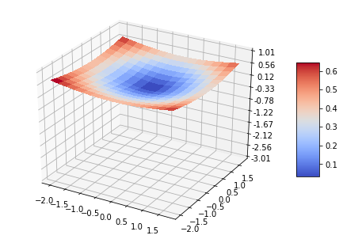

```python
import matplotlib.pyplot as plt
from matplotlib import cm, ticker
from matplotlib.ticker import LinearLocator
from mpl_toolkits.mplot3d import axes3d, Axes3D

import numpy as np

fig = plt.figure()
ax = Axes3D(fig)

# Make data
x = np.arange(-2, 2, 0.25)
y = np.arange(-2, 2, 0.25)
X, Y = np.meshgrid(x, y)
R = np.sqrt(X**2 + Y**2)
Z = R**1.2 / 5

# Plot the surface
surf = ax.plot_surface(X, Y, Z, cmap=cm.coolwarm,
                       linewidth=0, antialiased=False)

# Customize the z axis.
ax.set_zlim(-3.01, 1.01)
ax.zaxis.set_major_locator(LinearLocator(10))
# A StrMethodFormatter is used automatically
ax.zaxis.set_major_formatter(ticker.StrMethodFormatter("{x:.02f}"))

# Add a color bar which maps values to colors.
fig.colorbar(surf, shrink=0.5, aspect=5)

plt.show()
```

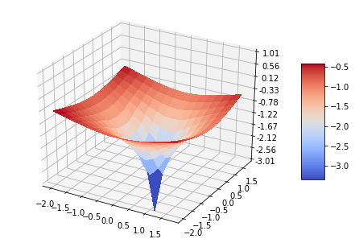

```python
import matplotlib.pyplot as plt
from matplotlib import cm, ticker
from matplotlib.ticker import LinearLocator
from mpl_toolkits.mplot3d import axes3d, Axes3D

import numpy as np

fig = plt.figure()
ax = Axes3D(fig)

# Make data
x = np.arange(-2, 2, 0.25)
y = np.arange(-2, 2, 0.25)
X, Y = np.meshgrid(x, y)
R = np.sqrt(X**2 + Y**2)
Z = np.log(1e-2 + R**1.2 / 5)

# Plot the surface
surf = ax.plot_surface(X, Y, Z, cmap=cm.coolwarm,
                       linewidth=0, antialiased=False)

# Customize the z axis.
ax.set_zlim(-3.01, 1.01)
ax.zaxis.set_major_locator(LinearLocator(10))
# A StrMethodFormatter is used automatically
ax.zaxis.set_major_formatter(ticker.StrMethodFormatter("{x:.02f}"))

# Add a color bar which maps values to colors.
fig.colorbar(surf, shrink=0.5, aspect=5)

plt.show()
```

### Примеры: априорные распределения Гаусса и Лапласа

Пусть веса $w_j$ независимы, $Ew_j = 0, Dw_j = С$

- Распределение Гаусса и квадратичный ($L_2$) регуляризатор:

$P(w; С) = \frac{1}{(2\pi C)^{n/2}} exp \left(-\frac{\|w\|^2_2}{2C}\right), \|w\|^2_2 = \sum\limits_{j=1}^n w_j^2$,

$-\log P(w; С) = \frac{1}{2C}\|w\|^2_2 + const$

- Распределение Лапласа и абсолютный ($L_1$) регуляризатор: $P(w; С) = \frac{1}{(2C)^{n}} exp \left(-\frac{\|w\|_1}{C}\right), \|w\|_1 = \sum\limits_{j=1}^n |w_j|$,

$-\log P(w; С) = \frac{1}{C}\|w\| + const$

$C$ — гиперпараметр, $\tau = \frac{1}{C}$ — коэффициент регуляризации

### Двухклассовая логистическая регрессия

- Линейная модель классификации для двух классов $Y = \{-1, 1\}$:

$а(x) = sign \left<w, x\right>,\ x, w ∈ \mathbb{R}^n$, отступ $M = \left<w, x\right>y$

- Логарифмическая функция потерь:

$\mathcal{L}(M) = \log(1 + e^{-M})$

- Модель условной вероятности:

$P(y|x, w) = \sigma(M) = \frac{1}{1 + e^{-M}},$

где $\sigma(M)$ — сигмоидная функция, важное свойство: $\sigma(M) + \sigma(-M) = 1$

- Задача обучения регуляризованной логистической регрессии (минимизация аппроксимированного эмпирического риска):

$Q(w) = \sum\limits_{i=1}^\ell \log (1 + \exp(-\left<w, x_i\right>y_i)) + \frac{\tau}{2}\|w\|^2_2 \to \min\limits_w $

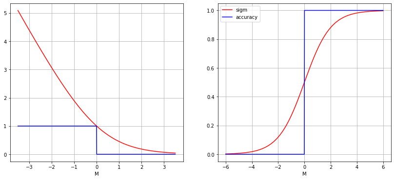

```python
import matplotlib.pyplot as plt
import numpy as np

fig, (ax1, ax2) = plt.subplots(1, 2)

ax1.set_xlabel('M')
ax2.set_xlabel('M')

x1 = np.linspace(-3.5, 3.5, num=1000)
L_M = np.log2(1 + np.exp(-x1)) # what if np.log used?
ax1.plot(x1, L_M, 'r', label='loss')
ax1.plot(x1, x1 < 0, 'b', label='acc loss')

x2 = np.linspace(-6, 6, num=1000)
sigm_M = 1 / (1 + np.exp(-x2))
ax2.plot(x2, sigm_M, 'r', label='sigm')
ax2.plot(x2, x2 > 0, 'b', label='accuracy')

ax1.grid(True)
ax2.grid(True)

fig.set_size_inches(14, 6)

plt.legend(loc='best')
plt.show()
```

### Многоклассовая логистическая регрессия

Линейный классификатор при произвольном числе классов $|Ү|$:

$\color{red}{a(x) = \arg\max\limits_{y \in Y} \left< w_y, x\right>},\ x, w_y \in \mathbb{R}^n$

Вероятность того, что объект $х$ относится к классу $y$:

$P(y|x,w) = \frac{\exp\left< w_y, x\right>}{\sum\limits_{z \in Y} \exp\left< w_z, x\right>} = \underset{y \in Y}{softmax} \left< w_y, x\right>$

Функция $softmax: \mathbb{R}^Y \to \mathbb{R}^Y$ переводит произвольный вектор в нормированный вектор дискретного распределения.

Максимизация правдоподобия (log-loss) с регуляризацией:

$ L(w) = \sum\limits_{i=1}^\ell \log P(y_i|w, x_i) - \frac{\tau}{2} \sum\limits_{y \in Y} \|w_y\|^2 \to \max\limits_w $

### Пример. Бинаризация признаков и скоринговая карта

Задача кредитного скоринга

- $x_i$ — заемщики
- $y_i$ — вернёт кредит (+1) или нет (-1)

| Признак $j$ | Интервал $k$ | $w_{jk}$ |
| --- | --- | --- |
| возраст | до 25 | 5 |
|  | 25-40 | 10 |
|  | 40-50 | 15 |
|  | 50+ | 5 |
| собственность | владелец | 20 |
|  | совладелец | 15 |
|  | съемщик | 10 |
|  | другое | 5 |
| работа | руководитель | 15 |
|  | менеджер | 10 |
|  | служащий | 5 |
|  | другое | 0 |
| стаж | менее 1 года | 0 |
|  | 1..3 | 5 |
|  | 3..10 | 10 |
|  | 10+ | 15 |

Бинаризация признаков $f_j(x)$: $b_{jk}(x) = [f_j(x)$ из $k$-го интервала$]$

Линейная модель классификации

$a(x, w) = sign (\sum\limits_{j,k} w_{jk} b_{jk}(x) - w_0)$

Вес признака $w_{jk}$ равен его вкладу в общую сумму баллов (score).

### Оценивание рисков в скоринге

Логистическая регрессия не только определяет веса $w$, но и оценивает апостериорные вероятности классов

$P(y | x) = \frac{1}{1 + \exp(-\left<w, x\right> y)}$

Оценка риска (математического ожидания) потерь объекта $x$:

$R(x) = \sum\limits_{y \in Y} D_{xy} P(y | x)$

где $D_{xy}$ — величина потери для объекта $x$ c исходом $y$. Оценка говорит о том, сколько мы потеряем в среднем.

**Вопрос 1:** Как оценить, сколько мы потеряем в худшем случае?

### Методика VaR (Value at Risk)

Стохастическое моделирование: $N = 10^4$ раз

- для каждого $x_i$ разыгрывается исход $y_i \sim P(y|x_i)$
- вычисляется сумма потерь по портфелю $V = \sum\limits_{i=1}^\ell D_{x_iy_i}$

99%-квантиль эмпирического распределения потерь определяет величину резервируемого капитала.

[figure not shown]

### Логическая закономерность

$X^\ell = (x_i, y_i)_{i=1}^\ell \subset X \times Y$ — обучающая выборка, $y_i = y(x_i)$

*Логическая закономерность* (правило, rule) — это предикат $R: X \in \{0, 1\}$, удовлетворяющий двум требованиям:

1. интерпретируемость:

   а) $R$ записывается на естественном языке;

   б) $R$ зависит от небольшого числа признаков (1-7);
2. информативность относительно одного из классов $c \in Y$:

   $p_c (R) = ＃\{x_i : R(x_i)=1 \text{ и } y_i =c\} \to \max$

   $n_c (R) = ＃\{x_i : R(x_i)=1 \text{ и } y_i \neq c\} \to \min$

Если $R(x) = 1$, то говорят «$R$ выделяет $х$» ($R$ covers $x$).

[figure not shown]

### Требование интерпретируемости

1) R(x) записывается на естественном языке

2) R(x) зависит от небольшого числа признаков (1-7)

#### Пример (из области медицины)

**Если** «возраст > 60» **и** «пациент ранее перенёс инфаркт», то операцию не делать, риск отрицательного исхода 60%.

#### Пример (из области кредитного скоринга)

**Если** «в анкете указан домашний телефон» **и** «зарплата > \$2000» **и** «сумма кредита < \$5000» то кредит можно выдать, риск дефолта 5%

### Основные шаги индукции правил (rulе іnduction)

1. Выбор семейства правил для поиска закономерностей
2. Порождение правил (rule generation)
3. Отбор правил-закономерностей (rule selection)

*Закономерность* — интерпретируемый высокоинформативный одноклассовый классификатор с отказами.

### Выбор семейства правил

1. Пороговое условие (решающий пень, decision stumр):

$R(x) = [f_j(x) \leq \color\red{a_j}] \text{ или } [\color\red{a_j} \leq f_j(x) \leq \color\red{b_j}]$

1. *Конъюнкция* пороговых условий:

$R(x) = \bigwedge\limits_{j \in \color\red{J}} [\color\red{a_j} \leq f_j(x) \leq \color\red{b_j}]$

1. *Синдром* — выполнение не менее $d$ условий из $|J|$ (при $d = |J|$ это конъюнкция, при $d = 1$ — дизъюнкция):

$R(x) = \left[\sum\limits_{j \in \color\red{J}} [\color\red{a_j} \leq f_j(x) \leq \color\red{b_j}] \geq \color\red{d}\right]$

Параметры $\color\red{J}, \color\red{a_j}, \color\red{b_j}, \color\red{d}$, настраиваются по обучающей выборке путём оптимизации *критерия информативности*.

### Выбор семейства правил

1. Полуплоскость — линейная пороговая функция:

$R(x) = \left[\sum\limits_{j \in \color\red{J}} \color\red{w_j} f_j(x) \geq \color\red{w_0}\right]$

1. *Шар* — пороговая функция близости:

$R(x) = [(\rho(x, \color\red{x_0}) \leq \color\red{w_0}]$

АВО — алгоритмы вычисления оценок [Ю.И. Журавлёв, 1971]

$\rho(x, \color\red{x_0}) = \max\limits_{j \in \color\red{J}} \color\red{w_j} |f_j(x) - f_j(\color\red{x_0})|$

SCM — машины покрывающих множеств [M. Marchand, 2001]

$\rho(x, \color\red{x_0}) = \sum\limits_{j \in \color\red{J}} \color\red{w_j} |f_j(x) - f_j(\color\red{x_0})|^\color\red{\gamma}$

Параметры $\color\red{J}, \color\red{w_j}, \color\red{w_0}, \color\red{x_0}, \color\red{\gamma}$, настраиваются по обучающей выборке путём оптимизации *критерия информативности*.

### Порождение правил

**Вход**: обучающая выборка $X^\ell$

**Выход**: множество закономерностей $Z$

1: начальное множество правил $Z$

2: **повторять**

3: $\ \ \ Z^\prime :=$ множество локальных модификаций правил $R \in Z$

4: $\ \ \ $ удалить слишком похожие правила из $Z \cup Z^\prime$

5: $\ \ \ Z :=$ наиболее информативные правила из $Z \cup Z^\prime$

6: **пока** правила продолжают улучшаться

7: **вернуть** $Z$

#### Частные случаи оптимизации

- генетические (эволюционные) алгоритмы
- управляемый локальный поиск (GLS) — меняем штрафы в процессе поиска
- метод ветвей и границ — отсекаем области, заведомо не содержащие оптимальных решений

**Вопрос 2:** Где используются упомянутые частные случаи?

### Локальные модификации правил

**Пример.** Семейство конъюнкций пороговых условий:

$R(x) = \bigwedge\limits_{j \in \color\red{J}} [\color\red{a_j} \leq f_j(x) \leq \color\red{b_j}]$

Локальные модификации конъюнктивного правила:

- варьирование одного из порогов $\color\red{a_j}$ или $\color\red{b_j}$
- варьирование обоих порогов $\color\red{a_j}$ и $\color\red{b_j}$ одновременно
- добавление признака $\color\red{f_j}$ в $J$ c варьированием порогов $\color\red{a_j}, \color\red{b_j}$
- удаление признака $\color\red{f_j}$ из $J$

При удалении признака (pruning) информативность обычно оценивается по контрольной выборке (hold-out)

Для оптимизации множества $J$ подходят те же методы, что и для отбора признаков (feature selection)

### Отбор закономерностей по паре критериев $p_c \to \max, n_c \to \min$

**Парето-фронт** — множество неулучшаемых закономерностей (точка неулучшаема, если правее и ниже неё точек нет)

[figure not shown]

**Проблема**: хотелось бы иметь один скалярный критерий

### Комплексные признаки информативности

- энтропийный критерий прироста информации:

  $ ІGain(p, n) = h\left(\frac{P}{\ell} \right) - \frac{p+n}{\ell} h\left(\frac{p}{p+n} \right) - \frac{\ell-p-n}{\ell} h\left(\frac{P-p}{\ell-p-n} \right) \to \max \\ h(q) = -q log_2 q - (1-q) log_2 (1 - q)\ — \text{энтропия «распределения двух классов»} $
- критерий Джини (Gini imрurity):

  $IGini(p, n) = IGain(p, n)$ при $h(q) = 4q(1 — q)$
- точный статистический тест Фишера (Fisher's Exact Test):

  $IStat(p, n) = -\frac{1}{\ell} log_2 \frac{C_P^pC_N^n}{C_{P+N}^{p+n}} \to \max$ — это просто вероятность реализации такой пары $p, n$
- критерий бустинга [Cohen, Singer, 1999](http://www.cs.utsa.edu/~bylander/cs6243/aaai-99-slipper.pdf)

  $\sqrt{p} - \sqrt{n} \to \max$
- нормированный критерий бустинга:

  $\sqrt{\frac{p}{P}} - \sqrt{\frac{n}{N}} \to \max$

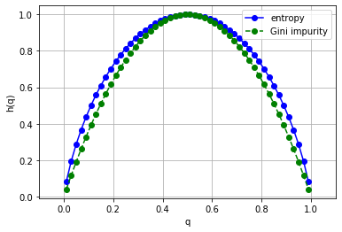

```python
import matplotlib.pyplot as plt

_, ax = plt.subplots()

q = np.linspace(0.01, 0.99, num=50)
h_q = -q * np.log2(q) - (1 - q) * np.log2(1 - q)
h_q_2 = 4 * q * (1 - q)

ax.set_xlabel('q')
ax.set_xlim(-0.1, 1.1)
ax.set_ylabel('h(q)')

ax.plot(q, h_q, 'bo-', label='entropy')
ax.plot(q, h_q_2, 'go--', label='Gini impurity')
ax.grid(True)

plt.legend(loc='best')
plt.show()
```

### Комбинированное использование закономерностей

- Взвешенное голосование (линейный классификатор с весами $w_{yt}$):

  $ a(x) = \arg\max\limits_{y \in Y} \sum\limits_{t=1}^{T_y} w_{yt} R_{yt}(x)$
- Простое голосование (комитет большинства)

  $ a(x) = \arg\max\limits_{y \in Y} \frac{1}{T_y}\sum\limits_{t=1}^{n_y} R_{yt}(x)$
- Решающий список (комитет старшинства), $c_t \in Y$:

[figure not shown]

### Решающее дерево (Decision Tree)

Решающее дерево — алгоритм классификации $a(x)$, задающийся деревом (связным ациклическим графом)

1. $V = V_{\text{внутр}} \cup V_{\text{лист}} $, $v_0 \in V$ — корень дерева
2. $v \in V_{\text{внутр}}$: функции $f_v: X \to D_v$ и $S_v: D_v \to V,\ |D_v| < \infty$
3. $v \in V_{\text{лист}}$: метка класса $y_v \in Y$

**Частный случай**: $D_v = \{0, 1\}$ — бинарное решающее дерево

**Пример**: $f_v(x) = [f_j(x) \geq \theta_j]$

[figure not shown]

### Пример

[Ирисы Фишера](https://ru.wikipedia.org/wiki/Ирисы_Фишера) – классический датасет для классификации.

Классы: Ирис щетинистый (Iris setosa), Ирис виргинский (Iris virginica), Ирис разноцветный (Iris versicolor)

Признаки: Длина/ширина чашелистика, Длина/ширина лепестка.

[figure not shown]

```python
import numpy as np

from sklearn.datasets import load_iris
X, y = load_iris(return_X_y=True)

features = np.array(["длина чашелистика", "ширина чашелистика",
                  "длина лепестка", "ширина лепестка"])
labels = np.array(["щетинистый", "виргинский", "разноцветный"])
```

```python
def show_legend():
    cb = plt.colorbar()
    loc = [0, 1, 2]
    cb.set_ticks(loc)
    cb.set_ticklabels(labels)
```

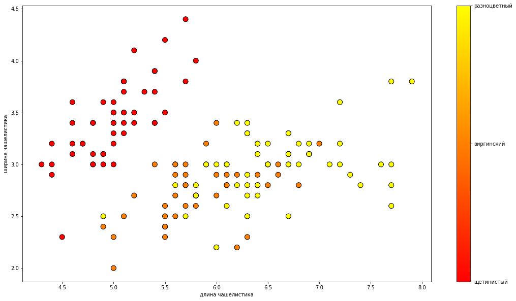

```python
import matplotlib.pyplot as plt

plt.figure(figsize=(18.0, 10.0))
plt.scatter(X[:, 0], X[:, 1], c=y, s=100, cmap='autumn', edgecolors="black")
plt.xlabel(features[0])
plt.ylabel(features[1])
show_legend()
```

```python
from sklearn.linear_model import LogisticRegression
clf = LogisticRegression(random_state=0, C=1.0).fit(X, y)
clf.predict(X)
```

```
array([0, 0, 0, 0, 0, 0, 0, 0, 0, 0, 0, 0, 0, 0, 0, 0, 0, 0, 0, 0, 0, 0,
       0, 0, 0, 0, 0, 0, 0, 0, 0, 0, 0, 0, 0, 0, 0, 0, 0, 0, 0, 0, 0, 0,
       0, 0, 0, 0, 0, 0, 1, 1, 1, 1, 1, 1, 1, 1, 1, 1, 1, 1, 1, 1, 1, 1,
       1, 1, 1, 1, 2, 1, 1, 1, 1, 1, 1, 2, 1, 1, 1, 1, 1, 2, 1, 1, 1, 1,
       1, 1, 1, 1, 1, 1, 1, 1, 1, 1, 1, 1, 2, 2, 2, 2, 2, 2, 1, 2, 2, 2,
       2, 2, 2, 2, 2, 2, 2, 2, 2, 2, 2, 2, 2, 2, 2, 2, 2, 2, 2, 2, 2, 2,
       2, 2, 2, 2, 2, 2, 2, 2, 2, 2, 2, 2, 2, 2, 2, 2, 2, 2])
```

```python
clf.predict_proba(X[:2, :])
```

```
array([[9.81797141e-01, 1.82028445e-02, 1.44269293e-08],
       [9.71725476e-01, 2.82744937e-02, 3.01659208e-08]])
```

```python
clf.score(X, y)
```

```
0.9733333333333334
```

**Вопрос 3:** Как считается score?

[Ответ](https://scikit-learn.org/stable/modules/generated/sklearn.linear_model.LogisticRegression.html#sklearn.linear_model.LogisticRegression): mean accuracy

Напишем вспомогательную функцию, которая будет возвращать решетку для дальнейшей красивой визуализации

```python
def get_grid(data):
    x_min, x_max = data[:, 0].min() - 1, data[:, 0].max() + 1
    y_min, y_max = data[:, 1].min() - 1, data[:, 1].max() + 1
    return np.meshgrid(np.arange(x_min, x_max, 0.01),
                       np.arange(y_min, y_max, 0.01))
```

Напишем функцию для обучения на данных, предсказания ответа для каждой точки решетки и визуализации результата. Т.к. данные гораздо лучше разделяются по лепесткам, визуализируем только их (параметры чашелистика возьмем средние).

```python
def plot_model(X, y, clf, proba=False, legend=True):
    clf.fit(X, y)
    xx2, xx3 = get_grid(X[:, [2,3]])
    shape = xx2.ravel().shape
    grid_xs = np.c_[np.full(shape, X[:,0].mean()),
                    np.full(shape, X[:,1].mean()),
                    xx2.ravel(),
                    xx3.ravel()]
    predicted = clf.predict(grid_xs).reshape(xx2.shape)
    if proba:
        probs = clf.predict_proba(grid_xs)
        confidence = probs.max(axis=1).reshape(xx2.shape)
        mesh = plt.pcolormesh(xx2, xx3, confidence, cmap='autumn')
    else:
        mesh = plt.pcolormesh(xx2, xx3, predicted, cmap='autumn')
    plt.scatter(X[:, 2], X[:, 3], c=y, s=150, cmap='autumn', alpha=0.7, edgecolors="black")
    plt.ylim([xx3.min(),xx3.max()])
    plt.xlim([xx2.min(),xx2.max()])
    plt.xlabel(features[2])
    plt.ylabel(features[3])
    if legend:
        if not proba:
            show_legend()
        else:
            cb = plt.colorbar(mesh)
    return clf
```

```
LogisticRegression(C=1.0, class_weight=None, dual=False, fit_intercept=True,
                   intercept_scaling=1, l1_ratio=None, max_iter=100,
                   multi_class='auto', n_jobs=None, penalty='l2',
                   random_state=None, solver='lbfgs', tol=0.0001, verbose=0,
                   warm_start=False)
```

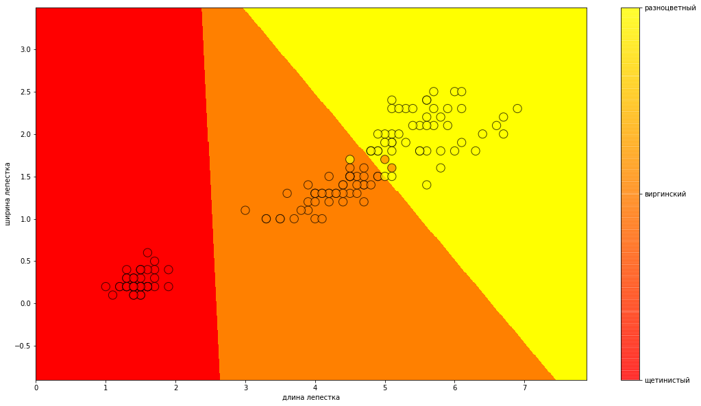

```python
plt.figure(figsize=(18.0, 10.0))
plot_model(X, y, LogisticRegression())
```

```
LogisticRegression(C=1.0, class_weight=None, dual=False, fit_intercept=True,
                   intercept_scaling=1, l1_ratio=None, max_iter=100,
                   multi_class='auto', n_jobs=None, penalty='l2',
                   random_state=None, solver='lbfgs', tol=0.0001, verbose=0,
                   warm_start=False)
```

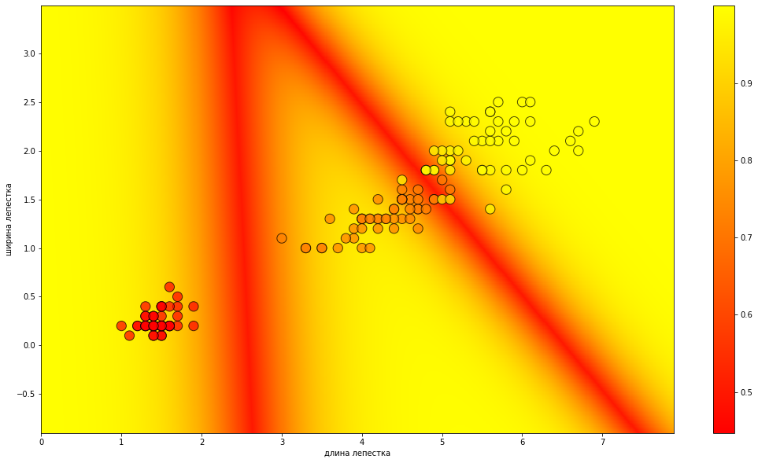

```python
plt.figure(figsize=(18.0, 10.0))
plot_model(X, y, LogisticRegression(), proba=True)
```

### Решающие деревья

```
DecisionTreeClassifier(ccp_alpha=0.0, class_weight=None, criterion='gini',
                       max_depth=None, max_features=None, max_leaf_nodes=None,
                       min_impurity_decrease=0.0, min_impurity_split=None,
                       min_samples_leaf=1, min_samples_split=2,
                       min_weight_fraction_leaf=0.0, presort='deprecated',
                       random_state=None, splitter='best')
```

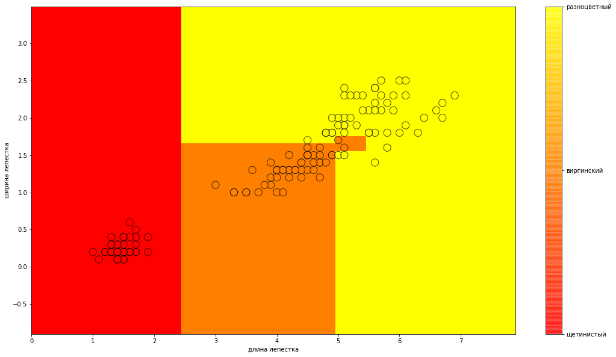

```python
from sklearn.tree import DecisionTreeClassifier
plt.figure(figsize=(18.0, 10.0))
plot_model(X, y, DecisionTreeClassifier())
```

```
DecisionTreeClassifier(ccp_alpha=0.0, class_weight=None, criterion='gini',
                       max_depth=None, max_features=None, max_leaf_nodes=None,
                       min_impurity_decrease=0.0, min_impurity_split=None,
                       min_samples_leaf=1, min_samples_split=2,
                       min_weight_fraction_leaf=0.0, presort='deprecated',
                       random_state=None, splitter='best')
```

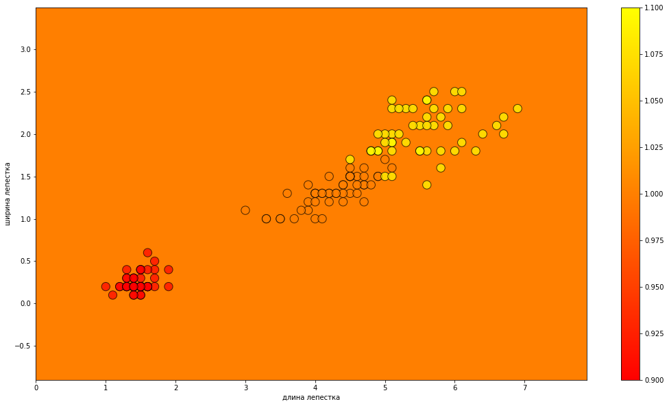

```python
plt.figure(figsize=(18.0, 10.0))
plot_model(X, y, DecisionTreeClassifier(), proba=True)
```

**Вопрос 4:** Уверенность модели везде близка к 1.0. Что произошло?

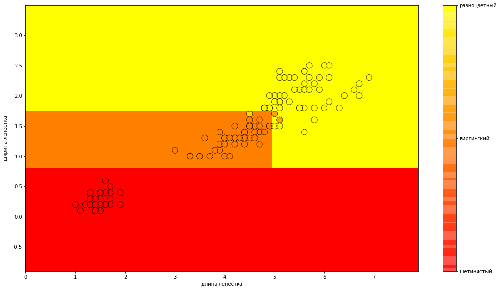

```python
plt.figure(figsize=(18.0, 10.0))
clf = plot_model(X, y, DecisionTreeClassifier(max_depth=3))
```

```
DecisionTreeClassifier(ccp_alpha=0.0, class_weight=None, criterion='gini',
                       max_depth=3, max_features=None, max_leaf_nodes=None,
                       min_impurity_decrease=0.0, min_impurity_split=None,
                       min_samples_leaf=1, min_samples_split=2,
                       min_weight_fraction_leaf=0.0, presort='deprecated',
                       random_state=None, splitter='best')
```

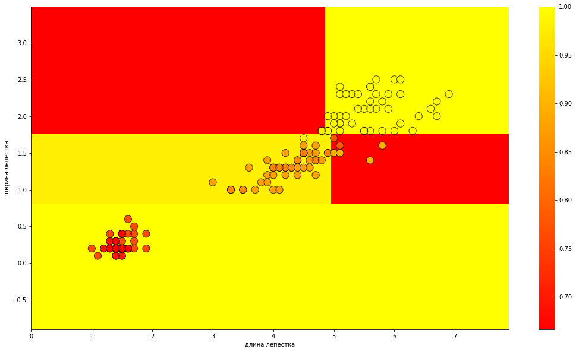

```python
plt.figure(figsize=(18.0, 10.0))
plot_model(X, y, DecisionTreeClassifier(max_depth=3), proba=True)
```

### Визуализация структуры дерева

```python
from sklearn.tree import plot_tree

def draw_decision_tree(clf, column_names):
    plt.figure(figsize=(18,10))
    plot_tree(clf, filled=True, feature_names=column_names)
    plt.show()
```

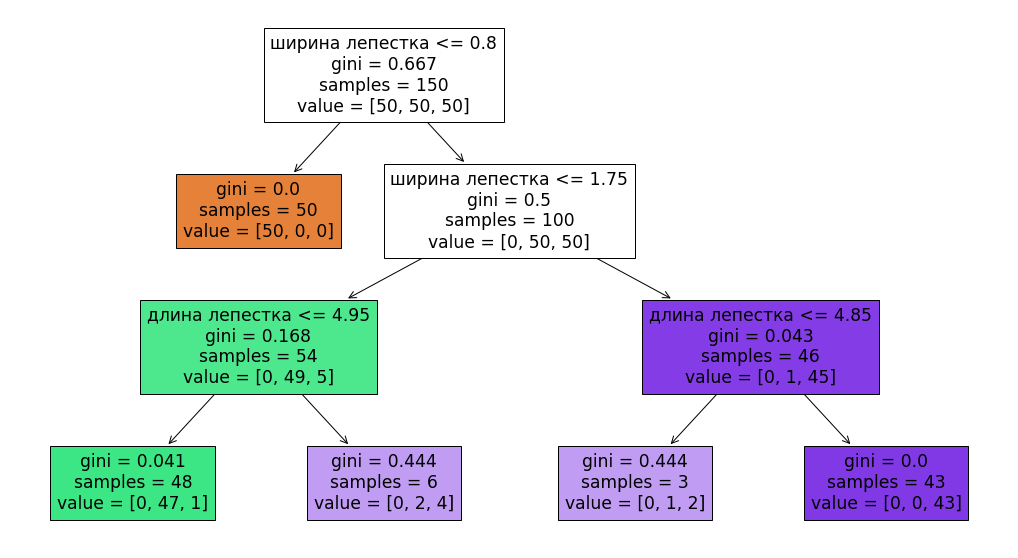

```python
draw_decision_tree(clf, features)
```

### Обучение решающего дерева. Алгоритм ID3

$v_0 := TreeGrowing(X^ℓ)$

1: **ФУНКЦИЯ** TreeGrowing($U \subset X^ℓ$) ↦ корень дерева $v$

2: **если** StopCriteria ($U$) **то**

3: $\ \ \ $ **вернуть** новый лист $v$, взяв $y_v := \text{Major} (U)$

4: найти признак, наиболее выгодный для ветвления дерева:

$f_v = \arg\max\limits_{f \in F} Gain(f, U)$

5: **если** $Gain (f_v, U) < G_0$ **то**

6: $\ \ \ $ **вернуть** новый лист $v$, взяв $y_v := \text{Major}(U)$

7: создать новую внутреннюю вершину $v$ с функцией $f_v$

8: **для всех** $k \in D_v$

$U_k = \{x \in U: f_v(x) = k\}, S_v(k) := TreeGrowing (U_k)$

9: **вернуть** $v$

Мажоритарное правило: $\text{Major}(U) := \arg\max P(y|U)$

### Мера неопределённости распределения

Частотная оценка вероятности класса $y$ в вершине $v \in V_{\text{внутр}}$:

$ p_y \equiv P(y|U) = \frac{1}{|U|} \sum\limits_{x_i \in U} [y_i = y] $

$\Phi(U)$ — мера неопределённости (impurity) распределения $p_y$:

[figure not shown]

1. минимальна, когда $p_y \in \{0,1\}$,
2. максимальна, когда $p_y = \frac{1}{|Y|}$ для всех $y \in Y$
3. симметрична: не зависит от перенумерации классов

$Ф(U) = E\mathcal{L}(p_y) = \sum\limits_{y \in Y} p_y \mathcal{L}(p_y) = \frac{1}{|U|} \sum\limits_{x_i \in U} \mathcal{L}(P(y_i| U)) \to \min $,

где $\mathcal{L}(p)$ убывает и $\mathcal{L}(1) = 0$, например: $-\log p, 1-р, 1-p^2$

### Критерий ветвления

Неопределённость распределений $P(y_i | U_k)$ после ветвления вершины $v$ по признаку $f$ и разбиения $U = \bigsqcup_{k \in D_v} U_k$:

$\Phi(U_1, \dots , U_{|D_v|}) = \frac{1}{|U|} \sum\limits_{x_i \in U} \mathcal{L}(P(y_i| U_{f(x_i)})) = \\ = \frac{1}{|U|} \sum\limits_{k \in D_v} \sum\limits_{x_i \in U_k} \mathcal{L}(P(y_i| U_{k})) = \sum\limits_{k \in D_v} \frac{|U_k|}{|U|} \Phi(U_k) $

Выигрыш от ветвления вершины $v$:

$\text{Gain} (f, U) = \Phi(U) - \Phi(U_1, \dots , U_{|D_v|}) = \Phi(U) - \sum\limits_{k \in D_v} \frac{|U_k|}{|U|} \Phi(U_k) \to \max\limits_{f \in F}$

### Критерий Джини и энтропийный критерий

Два класса, $Y = \{0, 1\}$, $P(y|U) = \left\{\begin{array}{@{}l@{}} q, &y = 1 \\ 1-q, &y = 0 \end{array}\right. $

- Если $\mathcal{L}(p) = -\log_2 p$, то

  $\Phi(U) = -q\log_2 q - (1-q) \log_2 (1-q)$ – энтропия выборки
- Если $\mathcal{L}(p) = 2(1 - p)$, то

  $\Phi(U) = 4q(1 - q) $ — неопределённость Джини (Gini imрurity)

### Обработка пропущенных значений

#### На стадии обучения

- $f_v(x_i)$ не определено $\Rightarrow\ x_i$ исключается из $U$ для $\text{Gain}(f_v, U)$
- $q_{vk} = \frac{|U_k|}{|U|}$ — оценка вероятности $k$-й ветви, $v \in V_{\text{внутр}}$
- $P(у|х, v) = \frac{1}{|U|} \sum\limits_{x_i \in U}[y_i = y]$ для всех $v \in V_{\text{лист}}$

#### На стадии классификации

- $f_v(x)$ определено $\Rightarrow$ из дочерней $s = S_v(f_v(x))$ взять $P(y|x, v) = P(y|x, ѕ)$
- $f_v(x)$ не определено $\Rightarrow$ пропорциональное распределение:

  $P(y|x, v) = \sum\limits_{k \in D_v} q_{vk} P(y | x, S_v(k)))$
- Окончательное решение — наиболее вероятный класс:

  $a(x) = \arg\max\limits_{y \in Y} P(y|x, v_0)$

### Жадная нисходящая стратегия: достоинства и недостатки

**Достоинства**:

- Интерпретируемость и простота классификации
- Гибкость: можно варьировать множество $F$
- Допустимы разнотипные данные и данные с пропусками
- Трудоёмкость линейна по длине выборки $O(|F|h\ell)$
- Не бывает отказов от классификации

**Недостатки**:

- Жадная стратегия переусложняет структуру дерева, и, как следствие, сильно переобучается
- Фрагментация выборки: чем дальше $v$ от корня, тем меньше статистическая надёжность выбора $f_v, y_v$
- Высокая чувствительность к шуму, к составу выборки, к критерию информативности

### Жадная стратегия переусложняет структуру дерева

[figure not shown]

### Усечение дерева (pruning)

$X^q$ — независимая контрольная выборка, $q ≈ 0.5\ell$

1: **для всех** $v \in V_{\text{внутр}}$

2: $X_v^q :=$ подмножество объектов $X^q$, дошедших до v

3: **если** $X_v^q = \emptyset$ **то**

4: $\ \ \ $ **вернуть** новый лист $v, y_v := \text{Major}(U)$

5: число ошибок при классификации $X_v^q$ разными способами:

$\ \ \ \text{Err}(v)$ — поддеревом, растущим из вершины v

$\ \ \ \text{Err}_k(v)$ — дочерним поддеревом $S_v(k), k \in D_v$

$\ \ \ \text{Err}_c(v)$ — классом $с \in Y$

6: в зависимости от того, какое из них минимально:

$\ \ \ $ cохранить поддерево $v$

$\ \ \ $ заменить поддерево $v$ дочерним $S_v(k)$

$\ \ \ $ заменить поддерево $v$ листом, $y_v := \arg\min\limits_{c \in Y} \text{Err}_c(v)$

### CART: деревья регрессии и классификации

Обобщение на случай регрессии: $Y = \mathbb{R}, y_v \in \mathbb{R}$

$C(a) = \sum\limits_{i=1}^\ell (a(x_i) - y_i)^2 \to \min\limits_a$

Пусть $U$ — множество объектов $x_i$, дошедших до вершины $v$

Мера неопределённости — среднеквадратичная ошибка

$ \Phi(U) = \min_{y \in Y} \frac{1}{|U|} \sum\limits_{x_i \in U} (y - y_i)^2 $

Значение $y_v$ в терминальной вершине $v$ — MHK-решение:

$y_v = \frac{1}{|U|} \sum\limits_{x_i \in U} y_i$

Дерево регрессии $a(x)$ — это кусочно-постоянная функция.

### Пример. Деревья регрессии различной глубины

Чем сложнее дерево (чем больше его глубина), тем выше влияние шумов в данных и выше риск переобучения.

https://scikit-learn.org/stable/auto_examples/tree/plot_tree_regression.html

[figure not shown]

### CART: критерий Minimal Cost-Complexity Pruning

Среднеквадратичная ошибка со штрафом за сложность дерева:

$C_\alpha(a) = \sum\limits_{i=1}^\ell (a(x_i) - y_i)^2 + \alpha |V_{\text{лист}}| \to \min\limits_\alpha$

При увеличении $\alpha$ дерево последовательно упрощается.

Причем последовательность вложенных деревьев единственна.

Из этой последовательности выбирается дерево с минимальной ошибкой на тестовой выборке (Hold-Out).

Для случая классификации используется аналогичная стратегия усечения, только с критерием Джини.

### Вспомогательная задача бинаризации вещественного признака

**Цель**: сократить перебор предикатов вида $[\color{red}{\alpha} \leq f(x) \leq \color{red}{\beta}]$

**Дано**: выборка значений вещественного признака $f(x_i), x_i \in X^l$

**Найти**: наилучшее (в каком-то смысле) разбиение области значений признака на относительно небольшое число зон:

$\zeta_0(x) = [f(x) < d_1]$

$\zeta_s(x) = [d_s \leq f(x) < d_{s+1}], s = 1, \dots, r-1$

$\zeta_r(x) = [d_r \leq f(x)]$

[figure not shown]

### Способы разбиения области значений признака на зоны

- Жадная максимизация информативности путём слияний
- Разбиение на равномощные подвыборки
- Разбиение по равномерной сетке «удобных» значений
- Объединение нескольких разбиений — например, равномерное и медианное

### Случайный лес (Random Forest)

Голосование деревьев классификации, $Y = \{-1, +1\}$

$a(t) = \text{sign} \frac{1}{T} \sum\limits_{t=1}^T b_t(x)$

Голосование деревьев регрессии, $Y = \mathbb{R}$

$a(t) = \text{sign} \frac{1}{T} \sum\limits_{t=1}^T b_t(x)$

- каждое дерево $b_t(x)$ обучается по случайной выборке с возвращениями
- в каждой вершине признак выбирается из случайного подмножества $\sqrt{n}$ признаков ($\lfloor n/3 \rfloor$ для регрессии)
- признаки и пороги выбираются по критерию Джини
- усечений (pruning) нет

### Резюме

- Логистическая регрессия — метод классификации, оценивающий условные вероятности классов $P(y|x)$
- Основные требования к логическим закономерностям:
  - интерпретируемость, информативность, различность
- Преимущества решающих деревьев:
  - интерпретируемость
  - допускаются разнотипные данные
  - возможность обхода пропусков
- Недостатки решающих деревьев:
  - переобучение
  - фрагментация
  - неустойчивость к шуму, составу выборки, критерию
- Способы устранения этих недостатков:
  - редукция
  - регуляризация
  - композиции (леса) деревьев